# 10a

Yiqiao Yin

3/23/2021

## Metropolis Algorithm

This is a self-learned introduction of *Metropolis Algorithm*. In the following, let me introduce the algorithm and lay out the steps of the procedure. Next, let us introduce diagnosis tools such as traceplot to visualize the fit.

In other words, the following notebook covers: - introduction - diagnosis

### Introduction

The Metropolis algorithm is common for acceptance or rejection. In other words, it is also known as acceptance/rejection sampling algorithm. It is an important concept in Bayesian inference.

At each step $t$, we draw a proposal distribution. This new draw can be accepted or rejected according to a certain threshold. The threshold is dependent on the ratio of the evaluated density at the proposal and the previous step $t-1$. Consider a proposal distribution $q(\theta^*|\theta^{t-1})$. It is required for this algorithm that this $q(\cdot)$ is symmetric. Let us state the algorithm

- Draw a starting data $\theta_0$
- For $t = 1, 2, ...$: let us
  - sample $\theta^*$ from the proposal distribution $p(\theta^*|\theta^{t-1})$;
  - compute the ratio of the target densities evaluated at $\theta^*$ and $\theta^{t-1}$, that is,
    $$s = p(\theta^*|y) / p(\theta^{t-1}|y)$$
  - set $\theta^t$ to be $\theta^*$ with probability $\min(s,1)$ and $\theta^{t-1}$ otherwise.

In order to demonstrate the procedure of the algorithm, let us create a toy data that has an independent variable $x$ and a dependent variable $y$. Let us further assume the data to have linear relationship between independent variable and the dependent variable. In other words, let us suppose
$$y = \beta_0 + \beta_1 X + \epsilon, \text{ while } \epsilon \sim \mathcal{N}(0, \sigma)$$

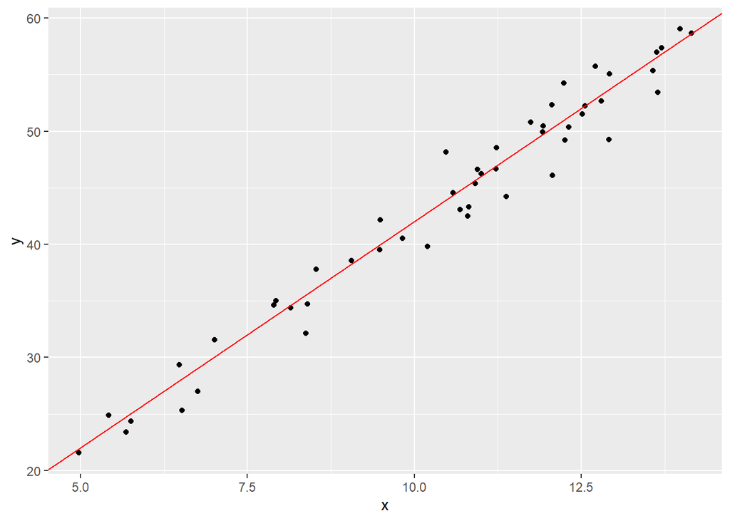

```r
# libraries
library(ggplot2)
library(gridExtra)
library(MHadaptive)
library(MCMCpack)

# set up parameters
sampleNum <- 50
b0 <- 2
b1 <- 4
sd <- 2

# simulate data
x <- rnorm(sampleNum, 10, sqrt(5))
y <- b0 + b1*x + rnorm(sampleNum, 0, sd)

# plot data
df <- data.frame(x, y)
g1 <- ggplot(df, aes(x=x, y=y)) + geom_point() + geom_abline(slope = b1, intercept = b0, col = "red")
g1
```

The summary of linear regression model can be reported using *lm()* below.

```r
# for reference
summary(lm(y~x))
```

```
##
## Call:
## lm(formula = y ~ x)
##
## Residuals:
##     Min      1Q  Median      3Q     Max
## -4.2453 -1.0096  0.0967  1.3841  4.4289
##
## Coefficients:
##             Estimate Std. Error t value Pr(>|t|)
## (Intercept)   1.7675     1.1734   1.506    0.139
## x             4.0038     0.1094  36.611   <2e-16 ***
## ---
## Signif. codes:  0 '***' 0.001 '**' 0.01 '*' 0.05 '.' 0.1 ' ' 1
##
## Residual standard error: 1.938 on 48 degrees of freedom
## Multiple R-squared:  0.9654, Adjusted R-squared:  0.9647
## F-statistic:  1340 on 1 and 48 DF,  p-value: < 2.2e-16
```

Now let us define a function to evaluate the likelihood of the model.

```r
posterior <- function(param){

    # take the input parameters of the intercept, slope and std dev
    b0 <- param[1]
    b1 <- param[2]
    sd <- param[3]

    # compute the expected value given the input parameters
    y_hat <- b0 + b1*x

    # compute the log likelihoods
    loglikelihoods <- dnorm(y, mean = y_hat, sd = sd, log = T)

    # sum the log likelihoods and return
    sumll <- sum(loglikelihoods)

    # priors - non-formative
    b0_prior <- dnorm(b0, sd=5, log=TRUE)
    b1_prior <- dnorm(b1, sd=5, log=TRUE)
    sd_prior <- dnorm(sd, sd=5, log=TRUE)

    # now return the sum of all components
    return(sum(sumll, b0_prior, b1_prior, sd_prior))
}
```

```r
# MH algorithm
metropolisMCMC <- function(theta0, proposal_sd, iter, burnin){

    # initialize the chain
    chain = matrix(NA, nrow=iter+1, ncol=length(theta0))
    chain[1,] = theta0
    acceptance <- rep(0, iter)

    # each interaction take a draw from the proposal for each parameter
    # calculate the acceptance probability
    # either accept or reject the proposal given the probability r
    for (i in 1:iter){
      theta_star <- rnorm(3, mean = chain[i,], sd = proposal_sd)
      r <- exp(posterior(theta_star) - posterior(chain[i,]))
      if (runif(1) < r){
          chain[i+1,] = theta_star
          acceptance[i] <- 1
      }else{
          chain[i+1,] = chain[i,]
      }
    }
    cat("Acceptance rate:", mean(acceptance[burnin:iter]))
    return(chain[burnin:iter,])
}

theta0 <- c(1, 2, 1)
prop_sd <- c(0.5, 0.1, 0.25)
its <- 50000
burn <- 5000
chain <- metropolisMCMC(theta0, prop_sd, its, burn)
```

```
## Acceptance rate: 0.2051066
```

### Diagnosis

With the above algorithm coded, we now want to use some visualization techniques such as trace plot to diagnose if the model is a good fit or not.

```r
# select burn in
colnames(chain) <- c("b0", "b1", "sd")
burnt_chain_df <- cbind(data.frame(chain), data.frame(iter = 1:nrow(chain)))

# plot function
posterior_densities <- function(){
  # initialize list
  gg_list <- list()

  # create plots and store in a list
  gg_list[["b0"]] <- ggplot(burnt_chain_df[,c("iter", "b0")], aes(x=b0, y=..density..)) +
    geom_histogram(fill = "darkcyan", col = "black") +
    geom_area(stat="density", fill="darkcyan", alpha=0.5) +
    geom_vline(xintercept = b0, col="red", lty=2) +
    geom_vline(aes(xintercept = mean(b0)), lty=2) +
    labs(title="b0 posterior")

  gg_list[["b1"]] <- ggplot(burnt_chain_df[,c("iter", "b1")], aes(x=b1, y=..density..)) +
    geom_histogram(fill = "darkcyan", col = "black") +
    geom_area(stat="density", fill="darkcyan", alpha=0.5) +
    geom_vline(xintercept = b1, col="red", lty=2) +
    geom_vline(aes(xintercept = mean(b1)), lty=2) +
    labs(title="b1 posterior")

  gg_list[["sd"]] <- ggplot(burnt_chain_df[,c("iter", "sd")], aes(x=sd, y=..density..)) +
    geom_histogram(fill = "darkcyan", col = "black") +
    geom_area(stat="density", fill="darkcyan", alpha=0.5) +
    geom_vline(xintercept = sd, col="red", lty=2) +
    geom_vline(aes(xintercept = mean(sd)), lty=2) +
    labs(title="sd posterior")

  gg_list[["b0_trace"]] <- ggplot(burnt_chain_df[,c("iter", "b0")], aes(x=iter, y=b0)) +
    geom_line() +
    geom_hline(aes(yintercept = mean(b0))) +
    geom_hline(yintercept = b0, col="red") +
    labs(title="b0 trace")

  gg_list[["b1_trace"]] <- ggplot(burnt_chain_df[,c("iter", "b1")], aes(x=iter, y=b1)) +
    geom_line() +
    geom_hline(aes(yintercept = mean(b1))) +
    geom_hline(yintercept = b1, col="red") +
    labs(title="b1 trace")

  gg_list[["sd_trace"]] <- ggplot(burnt_chain_df[,c("iter", "sd")], aes(x=iter, y=sd)) +
    geom_line() +
    geom_hline(aes(yintercept = mean(sd))) +
    geom_hline(yintercept = sd, col="red") +
    labs(title="sd trace")


  # arrange plots in a grid
  return(grid.arrange(grobs=gg_list, nrow=3, ncol=2, as.table=F))
}
```

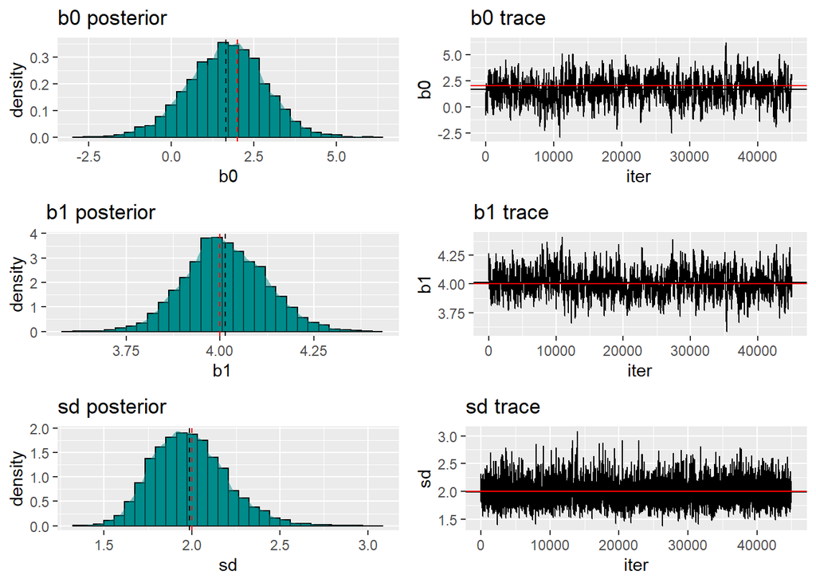

```r
posterior_densities()
```

Comment:

With the diagnosis above us, let us make the following observations:

- The fit is not perfect. For example, we know from the underlying model that $\beta_0$ is 2. However, this is not exactly what we see in the plot above. For the posterior distribution for $\beta_0$ after the simulation above the red dotted line $\beta_0 = 2$ is not really at the center of the distribution. In other words, there is still room for improvement. In addition, we observe the same pattern for $\beta_1$ since the red dotted line $\beta_1 = 4$ is not at the center of the distribution either.
- After the burn-in periods, the traceplots look relatively healthy and convergent. Hence, this is a good sign. However, since the mean is not really at the desired values for ground truth. There is place for improvement.

```r
report = rbind(
  apply(chain, 2, mean),
  apply(chain, 2, sd) )
rownames(report) = c("Mean", "SD")
data.table::data.table(report, keep.rownames = TRUE)
```

```
##      rn       b0        b1        sd
## 1: Mean 1.662223 4.0137248 1.9869476
## 2:   SD 1.149201 0.1072596 0.2098994
```

### Improvements

Let us revise the following algorithm, especially step 2:

- Draw a starting data $\theta_0$
- For $t = 1, 2, ...$: let us
  - sample $\theta^*$ from the proposal distribution $p(\theta^*|\theta^{t-1})$;
  - compute the ratio of the target densities evaluated at $\theta^*$ and $\theta^{t-1}$, that is,
    $$s = \frac{p(\theta^*|y)/ q_t(\theta^*|\theta_{t-1})}{p(\theta^{t-1}|y) / q_t(\theta_{t-1}|\theta^*)}$$
  - set $\theta^t$ to be $\theta^*$ with probability $\min(s,1)$ and $\theta^{t-1}$ otherwise.

```r
# Metropolis-Hastings algorithm
metropHastingsMCMC <- function(theta0, proposal_sd, iter, burnin){

    # initialise the chain
    chain = matrix(NA, nrow=iter+1, ncol=length(theta0))
    chain[1,] = theta0
    acceptance <- array(0, c(iter, length(theta0)))

    # each iteraction take a draw from the proposal for each parameter
    # calculate teh acceptance probability
    # either accept or reject the proposal given the probability r
    for (i in 1:iter){
      theta_star <- rnorm(3, mean = chain[i,], sd = proposal_sd)
      r <- exp(posterior(theta_star) - dnorm(theta_star, mean = chain[i,], sd = proposal_sd, log = T) -
               posterior(chain[i,]) + dnorm(chain[i,], mean = theta_star, sd = proposal_sd, log = T))

      # now that r is a vector of 3 values representing each parameter we need to accept/reject each individually
      for(k in 1:3){
          if (runif(1) < r[k]){
              chain[i+1,k] = theta_star[k]
              acceptance[i,k] <- 1
          }else{
              chain[i+1,k] = chain[i,k]
        }
      }
    }
    cat("Acceptance rate:", mean(acceptance[burnin:iter]))
    return(chain[burnin:iter,])
}

chain <- metropHastingsMCMC(theta0, prop_sd, its, burn)
```

```
## Acceptance rate: 0.2170618
```

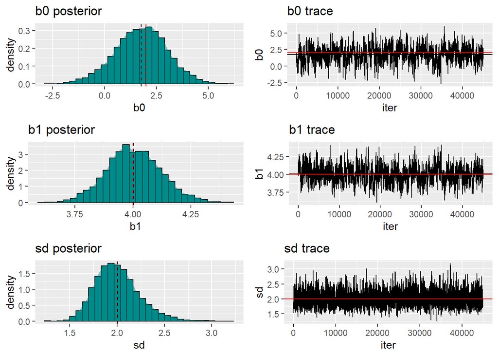

```r
# select burn in
colnames(chain) <- c("b0", "b1", "sd")
burnt_chain_df <- cbind(data.frame(chain), data.frame(iter = 1:nrow(chain)))

posterior_densities()
```

Comment:

Overall we observe improvement for this fit based on the revised threshold $s$ defined in step 2 of the improved algorithm.

Specifically, the first comment is that the mean of $\beta$’s fall in an range that is close to the ground truth. From the summary table below, we observe that posterior mean for $\beta_0$ and $\beta_1$ are closer to the theoretical values we know of. Moreover, it is also more apparent that the traceplot is convergent after the burn-in period with mean to be closer to the real values.

```r
report = rbind(
  apply(chain, 2, mean),
  apply(chain, 2, sd) )
rownames(report) = c("Mean", "SD")
data.table::data.table(report, keep.rownames = TRUE)
```

```
##      rn       b0        b1        sd
## 1: Mean 1.762715 4.0042258 2.0026417
## 2:   SD 1.238786 0.1159134 0.2309658
```